# Get started with optima

2023-6-28

```r
library(optima)
```

## Read in data in h5 format

Read in a real small dataset, called four cell mix.

```r
my.obj <- readHdf5(directory = "4-cell-lines-AML-multiomics.dna+protein.h5",
                   sample.name = "Four Cell Mix",
                   omic.type = "DNA+protein")
class(my.obj)
```

```
## [1] "optima"
## attr(,"package")
## [1] "optima"
```

The “optima” object is the core object in the optima package. simply run the object to view some summary statistics.

The optima object is defined as a S4 class, a user may also consider define your own optima object within R if they have appropriate data objects.

```r
my.obj
```

```
## optima object with:
## 1313 cells
## 27719 variants, data unfiltered
## 127 CNVs, data unnormalized
## 10 proteins, data unnormalized
## Current unique cell labels includes:  unassigned
```

To explore the object, you can use head() or dim() function to check matrices within the object. The rows represents the number of cells, the column represents number of variants being. Here we use the variant allele frequency matrix (vaf) matrix as example. It is an important matrix for downstream analysis.

```r
dim(my.obj$vaf.mtx)
```

```
## [1]  1313 27719
```

```r
names(my.obj)
```

```
##  [1] "meta.data"                "cell.ids"
##  [3] "cell.labels"              "variants"
##  [5] "variant.filter"           "vaf.mtx"
##  [7] "gt.mtx"                   "dp.mtx"
##  [9] "gq.mtx"                   "amps"
## [11] "amp.normalize.method"     "amp.mtx"
## [13] "ploidy.mtx"               "proteins"
## [15] "protein.normalize.method" "protein.mtx"
```

```r
print(my.obj$vaf.mtx[1:5, 1:3])
```

```
##         [,1]    [,2]     [,3]
## [1,] 2.00000 2.00000 0.000000
## [2,] 0.00000 0.00000 0.000000
## [3,] 0.00000 0.00000 0.000000
## [4,] 9.52381 9.52381 2.380952
## [5,] 0.00000 0.00000 0.000000
```

There are three types of analyses that can be done:

- 1. Variant
- 2. CNV
- 3. Protein

Here are some common analysis in those categories.

## 1. DNA analysis

The first step in DNA analysis is to filter the data set.

- Cells with too many low quality variants will be discarded
- Variants with too many low quality data points will be discarded

Within optima object, there is a label “variant.filter”, The label is “unfiltered” by default. The label will be changed to “filtered” once filterVariant() function is completed. In this example, the original 1313 cells in the original object gets filtered into 1271 cells, the 27719 variants gets filtered into 29 variants.

When conducting variant filtering, a user may choose to change the parameters in the filterVariant() function, There are 7 parameters that can be used in the filter process. They are min.dp, min.gq, vaf.ref, vaf.hom, vaf.het, min.cell.pt, min.mut.cell.pt. Check out the full description of each parameter by typing ?filterVariant()

```r
my.obj.filtered <- filterVariant(my.obj)
```

```
## Number of cells removed: 42
## Number of variants removed: 27690
```

```r
print(my.obj.filtered$variant.filter)
```

```
## [1] "filtered"
```

```r
print(dim(my.obj.filtered$vaf.mtx))
```

```
## [1] 1271   29
```

Notice here, variant data now shows “filtered” in the object summary.

```r
my.obj.filtered
```

```
## optima object with:
## 1271 cells
## 29 variants, data filtered
## 127 CNVs, data unnormalized
## 10 proteins, data unnormalized
## Current unique cell labels includes:  unassigned
```

You may check the VAF data after filtering.

```r
print(my.obj.filtered$vaf.mtx[1:5, 1:3])
```

```
##           [,1]     [,2] [,3]
## [1,]  52.83019 21.73913    0
## [2,] 100.00000  0.00000    0
## [3,] 100.00000  0.00000    0
## [4,] 100.00000  0.00000    0
## [5,]  44.44444 47.61905    0
```

Alternatively, the getDNAmtx() can be used to save DNA VAF data as a matrix from the optima object. The row names represents cell ID, the column names represents variant ID.

```r
DNA.mtx <- getDNAmtx(my.obj.filtered)
DNA.mtx[1:5, 1:3]
```

```
##                    chr1:115256669:G/A chr2:25458546:C/T chr2:25470426:C/T
## AACAACCTACTCTAGTAA           52.83019          21.73913                 0
## AACAACCTATCCTTAGGT          100.00000           0.00000                 0
## AACAACTGGAATCAGGAG          100.00000           0.00000                 0
## AACAACTGGAATGTGCGT          100.00000           0.00000                 0
## AACAACTGGATCGAATCG           44.44444          47.61905                 0
```

To get detailed information for each individual variant, The annotateVariant() function can be used. This function will generate a dataframe indicating the type of variant, associated genes, protein effect, etc.

```r
annotation.table <- annotateVariant(my.obj.filtered$variants)
```

```
## Retriving data from MissionBio...
## Done!
```

```r
head(annotation.table)
```

```
##                    variant_type transcript_id gene     protein
## chr1:115256669:G/A "SNV"        "NM_002524.5" "NRAS"   ""
## chr2:25458546:C/T  "SNV"        "NM_022552.5" "DNMT3A" ""
## chr2:25470426:C/T  "SNV"        "NM_022552.5" "DNMT3A" ""
## chr2:209113192:G/A "SNV"        "NM_005896.4" "IDH1"   "IDH1:p.G105="
## chr3:128200806:G/A "SNV"        "NM_032638.5" "GATA2"  ""
## chr4:55599436:T/C  "SNV"        "NM_000222.3" "KIT"    ""
##                    cDNA           protein_coding_impact function
## chr1:115256669:G/A "c.112-70C>T"  ""                    "intronic"
## chr2:25458546:C/T  "c.2597+30G>A" ""                    "intronic"
## chr2:25470426:C/T  "c.1014+34G>A" ""                    "intronic"
## chr2:209113192:G/A "c.315C>T"     "synonymous"          "coding"
## chr3:128200806:G/A "c.1018-19C>T" ""                    "intronic"
## chr4:55599436:T/C  "c.2484+78T>C" ""                    "intronic"
##                    allele_freq            DANN                dbSNP_id
## chr1:115256669:G/A ""                     "0.485702078310495" "rs969273"
## chr2:25458546:C/T  "0.5137756208872"      "0.551042207098605" "rs2304429"
## chr2:25470426:C/T  "0.000702189852540131" "0.635212256233406" "rs142243425"
## chr2:209113192:G/A "0.0505702877686397"   "0.680928983428449" "rs11554137"
## chr3:128200806:G/A "0.156403002496676"    "0.915158543656728" "rs11708606"
## chr4:55599436:T/C  ""                     "0.562532425916318" "rs1008658"
##                    clinvar  cosmic
## chr1:115256669:G/A "Benign" ""
## chr2:25458546:C/T  "Benign" ""
## chr2:25470426:C/T  ""       ""
## chr2:209113192:G/A "Benign" ""
## chr3:128200806:G/A "Benign" ""
## chr4:55599436:T/C  "Benign" ""
```

After filtering, we could manually assign clones names to the variant data. In the example below, we assign a label “my.cell” to all the cells in the dataset.

```r
my.obj.filtered$cell.labels <- rep("my.cell", length(my.obj.filtered$cell.labels))
head(my.obj.filtered$cell.labels)
```

```
## [1] "my.cell" "my.cell" "my.cell" "my.cell" "my.cell" "my.cell"
```

This can also be done using getClones function based on clustering results. The clustering results are stored in the cell.labels vector. Here we print the first 6 cell labels identified from the clustering method.

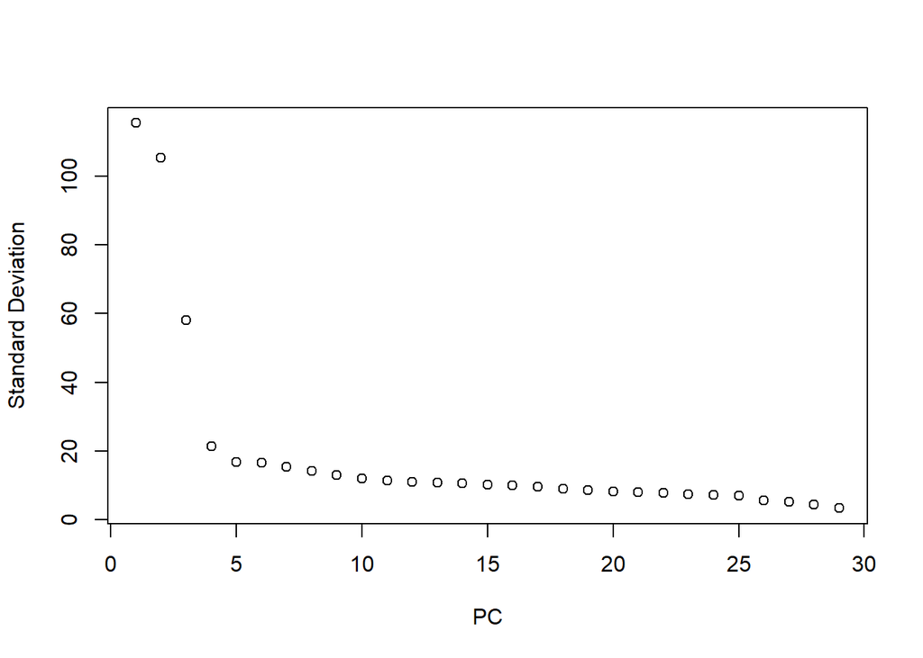

```r
elbowPlot(getDNAmtx(my.obj.filtered))
```

By looking at the elbow plot, the standard deviation (y axis) tends to be less after PC > 5 (x axis) and looks more flat. Thus we decide to use first 5 PC in the following getClones() step.

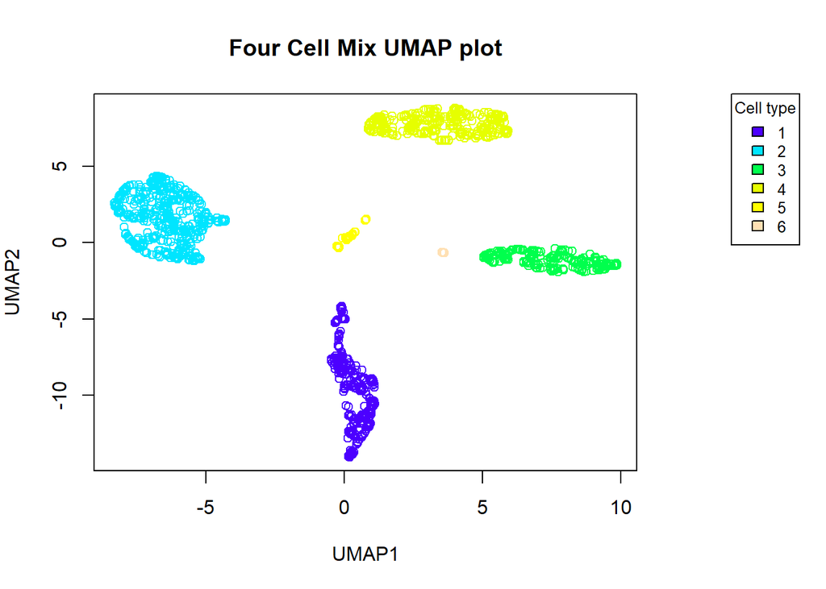

```r
set.seed(123)
clone.ret <- getClones(my.obj.filtered,
                       minPts = 20,
                       num.PC = 5,
                       plot = TRUE)
```

```r
my.obj.filtered <- clone.ret[[1]]
vaf.reduceDim <- clone.ret[[2]]
head(my.obj.filtered$cell.labels)
```

```
## [1] "1" "2" "2" "2" "1" "1"
```

```r
head(my.obj.filtered$cell.labels)
```

```
## [1] "1" "2" "2" "2" "1" "1"
```

As shown in the figure above, the getClone() function identified 6 clusters within the cell mixture. Meanwhile, the clustering result is stored as in the “cell.labels” vector in the “my.obj.filtered” object.

The getClones() function uses clustering algorithm dbscan to find distinct clusters within the cell population. So the labels generated by getClones() may not be identical to the ground truth. In order to get a better clustering result, we recommend users to tune the parameters, including eps and minPts.

If the primary goal of your study is to identify clones/subclones within the cell population, we recommend users to conduct manual verification of VAF data by expert with domain knowledge. Manually verified labels can then be assigned to my.obj.filtered$cell.labels object. See example above.

```r
my.obj.filtered
```

```
## optima object with:
## 1271 cells
## 29 variants, data filtered
## 127 CNVs, data unnormalized
## 10 proteins, data unnormalized
## Current unique cell labels includes:  1, 2, 3, 4, 5, 6
```

Once cell clone is determined, a heatmap can be used to visualize different cell populations

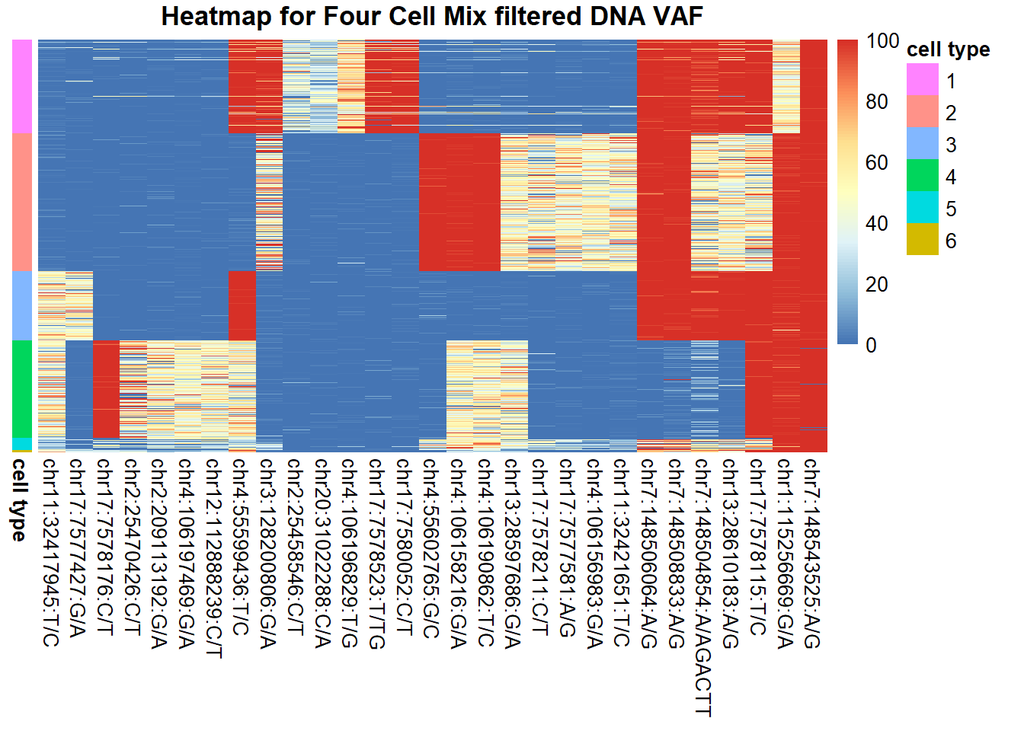

```r
drawHeatmap(my.obj.filtered, omic.type = "dna")
```

If a user is interested in one specific variant VAF level. They can create a feature plot based on the VAF dimension reduction result generated in previous step and color label each point based on VAF value.

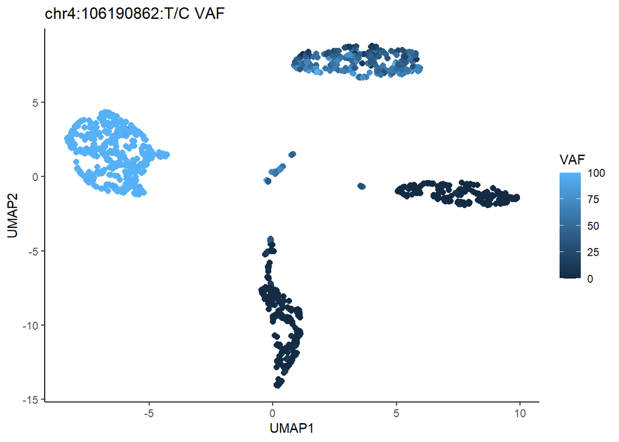

```r
plotVariantFeature(my.obj.filtered, "chr4:106190862:T/C", vaf.reduceDim)
```

## 2. CNV analysis

Check the dimension of cnv matrix. Notice here, the cells being filtered in DNA filter are also removed in CNV matrices, as well as protein matrices discussed below.

```r
dim(my.obj.filtered$amp.mtx)
```

```
## [1] 1271  127
```

```r
getCNVmtx(my.obj.filtered)[1:5, 1:3]
```

```
##                    AML_v2_NRAS_115256512 AML_v2_NRAS_115258635
## AACAACCTACTCTAGTAA                   103                   115
## AACAACCTATCCTTAGGT                    41                    30
## AACAACTGGAATCAGGAG                    25                    33
## AACAACTGGAATGTGCGT                    43                    34
## AACAACTGGATCGAATCG                    21                    20
##                    AML_v2_DNMT3A_25457166
## AACAACCTACTCTAGTAA                     67
## AACAACCTATCCTTAGGT                     40
## AACAACTGGAATCAGGAG                      8
## AACAACTGGAATGTGCGT                     12
## AACAACTGGATCGAATCG                     13
```

Normaliz CNV data. The normalized CNV matrix is stored in the amp.mtx data frame. There is also a amp.normalize.method label to indicate if this data object is normalized or not.

```r
my.obj.filtered$amp.normalize.method
```

```
## [1] "unnormalized"
```

```r
my.obj.filtered <- normalizeCNV(my.obj.filtered)
my.obj.filtered$amp.normalize.method
```

```
## [1] "normalized"
```

```r
getCNVmtx(my.obj.filtered)[1:5, 1:3]
```

```
##                    AML_v2_NRAS_115256512 AML_v2_NRAS_115258635
## AACAACCTACTCTAGTAA              2.106170              2.726909
## AACAACCTATCCTTAGGT              1.435809              1.218290
## AACAACTGGAATCAGGAG              1.676885              2.566811
## AACAACTGGAATGTGCGT              2.389801              2.191234
## AACAACTGGATCGAATCG              1.210175              1.336520
##                    AML_v2_DNMT3A_25457166
## AACAACCTACTCTAGTAA              2.4640475
## AACAACCTATCCTTAGGT              2.5193632
## AACAACTGGAATCAGGAG              0.9650978
## AACAACTGGAATGTGCGT              1.1994786
## AACAACTGGATCGAATCG              1.3473810
```

Summary shows CNV data normalized

```r
my.obj.filtered
```

```
## optima object with:
## 1271 cells
## 29 variants, data filtered
## 127 CNVs, data normalized
## 10 proteins, data unnormalized
## Current unique cell labels includes:  1, 2, 3, 4, 5, 6
```

Once the cnv data gets normalized. We could investigate the CNV for differnt cell populations. This is done by calculate ploidy. To do this there are two steps, step 1 we set one of the cell type as diploid (identified from DNA analysis), step 2 we calculate ploidy using the diploid cell type. Once Ploidy is calculated, you may use getPloidyMtx() function to get the ploidy matrix. The matrix row name is cell id, the column name is the CNV id.

```r
# diploid cell label
diploid.cell.label = 1

# calculate ploidy
my.obj.filtered <- calculatePloidy(my.obj.filtered,
                          diploid.cell = diploid.cell.label)
getPloidyMtx(my.obj.filtered)[1:5, 1:3]
```

```
##                    AML_v2_NRAS_115256512 AML_v2_NRAS_115258635
## AACAACCTACTCTAGTAA              1.878826              2.544770
## AACAACCTATCCTTAGGT              1.280825              1.136916
## AACAACTGGAATCAGGAG              1.495879              2.395365
## AACAACTGGAATGTGCGT              2.131841              2.044874
## AACAACTGGATCGAATCG              1.079547              1.247250
##                    AML_v2_DNMT3A_25457166
## AACAACCTACTCTAGTAA               2.573091
## AACAACCTATCCTTAGGT               2.630854
## AACAACTGGAATCAGGAG               1.007807
## AACAACTGGAATGTGCGT               1.252560
## AACAACTGGATCGAATCG               1.407008
```

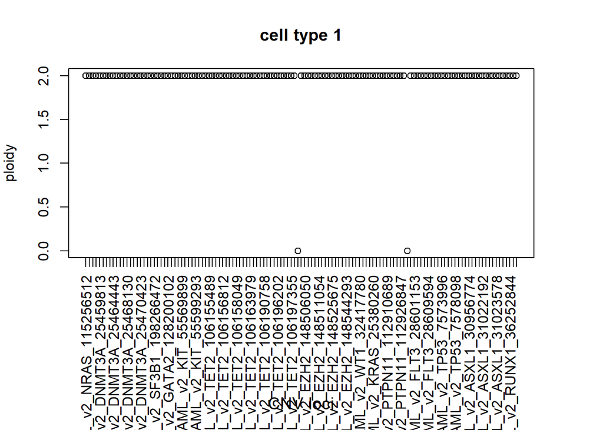

```r
plotPloidy(my.obj.filtered, cell.type = 1)
```

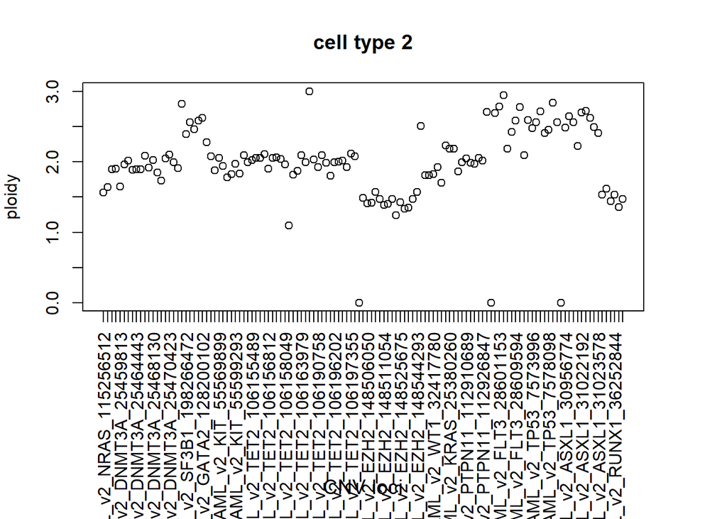

```r
plotPloidy(my.obj.filtered, cell.type = 2)
```

## 3. Protein analysis

The first step in protein analysis is to normalize the read counts using CLR. The input is raw counts, the output is the normalized counts represents protein expression.

```r
my.obj.filtered <- normalizeProtein(my.obj.filtered)
getProteinMtx(my.obj.filtered)[1:5, 1:3]
```

```
##                          CD11b       CD19        CD3
## AACAACCTACTCTAGTAA -0.01192553 -1.1105378 -1.1105378
## AACAACCTATCCTTAGGT -2.85338583  2.7149587 -2.0996140
## AACAACTGGAATCAGGAG -1.72939580  2.3396310 -2.4225430
## AACAACTGGAATGTGCGT -3.03570840  2.4081513 -2.2173981
## AACAACTGGATCGAATCG -0.08517522 -0.7783224 -0.7783224
```

```r
my.obj.filtered
```

```
## optima object with:
## 1271 cells
## 29 variants, data filtered
## 127 CNVs, data normalized
## 10 proteins, data normalized
## Current unique cell labels includes:  1, 2, 3, 4, 5, 6
```

Once the read counts are normalized, we could use dimension reduction to visualize cells in 2D space. The reduceDim() function will conduct PCA then UMAP methods on the protein data. The UMAP result will be used to project cells in a 2D space.

Within the plot, we saw that major clusters generated from protein expression level (clustered dots) are mostly belong to the same cell type label generated from DNA data (colors).

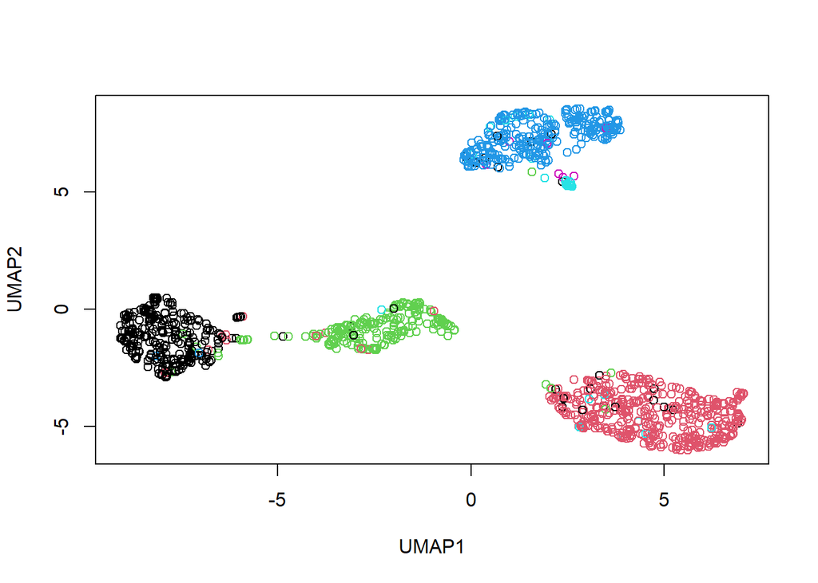

```r
# dimension reduction with PCA and UMAP.
protein.reduceDim <- reduceDim(my.obj.filtered$protein.mtx)
# plot UMAP coordinates after dimension reduction
plot(protein.reduceDim[[2]][[1]][,1],
     protein.reduceDim[[2]][[1]][,2],
     xlab = "UMAP1",
     ylab = "UMAP2",
     col = my.obj.filtered$cell.labels)
```

The drawHeatmap() function will take the protein matrix as input and draw a heatmap based on protein expression data.

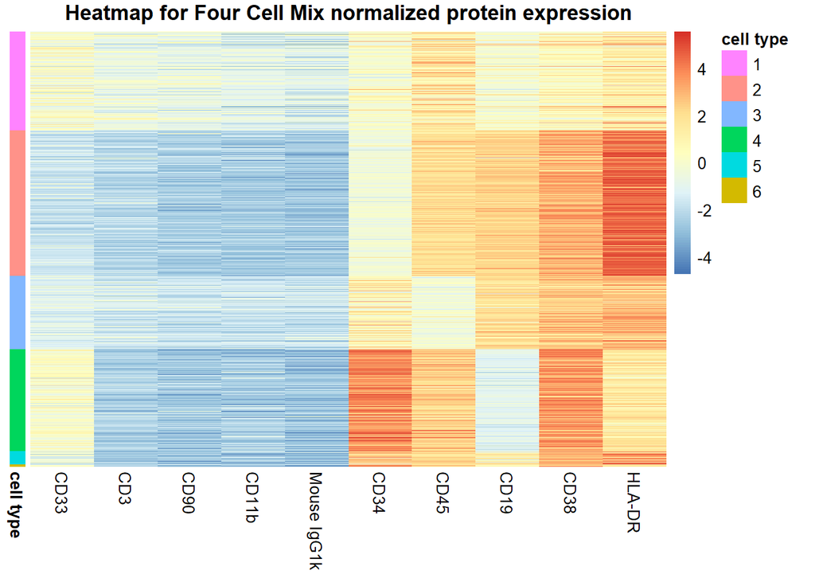

```r
# draw heatmap
drawHeatmap(my.obj.filtered, omic.type = "protein")
```

You can also find cell type signatures. Such signatures show different level of expression when compare with reference cell type with other cell types. This is done by comparing protein expression value in one cell type with all other cell types using t test.

```r
# find cell type signature for Jurkat cells
cell <- 1
signatures <- findSignature(my.obj.filtered, cell)
# a data frame that shows top DE proteins
print(signatures)
```

```
##                     p_val     p_val_adj  mean_diff
## CD38        1.117812e-145 1.117812e-144 -2.4471430
## CD90        1.898529e-123 9.492645e-123  1.6441318
## CD11b       7.719157e-107 2.573052e-106  1.3579776
## CD3         2.018302e-105 5.045756e-105  1.4062617
## HLA-DR       1.185160e-91  2.370320e-91 -1.7883154
## Mouse IgG1k  5.734318e-86  9.557197e-86  1.3358222
## CD19         5.141651e-54  7.345215e-54 -1.1264476
## CD33         6.970197e-50  8.712746e-50  1.0081925
## CD34         2.406982e-47  2.674425e-47 -1.1904653
## CD45         9.710182e-03  9.710182e-03 -0.2000146
```

If you are interested in looking at the expression level of one specific protein. You may query such protein with the plotProteinFeature() function. For example, the plot below shows the normalized expression level of “CD11b” protein in different cell clusters. Higher expression level is marked with lighter blue color.

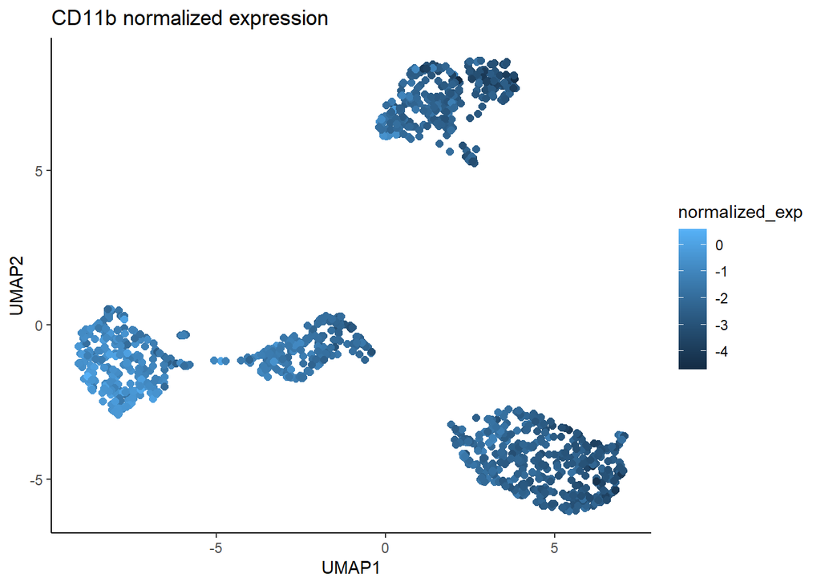

```r
plotProteinFeature(my.obj.filtered, "CD11b", protein.reduceDim)
```